# IODS course project

# IODS 3: Logistic regression

Daniel Kawecki 16.11.2019 Data on student performance and alcohol consumtion from https://archive.ics.uci.edu/ml/datasets/Student+Performance

```r
# access libraries
library(dplyr)
library(ggplot2)
```

## Reading the data

First, we read the data from the local file

```r
alc <- read.table(file = "data/alc.csv", sep = ";", header = TRUE)
glimpse(alc)
```

```
## Observations: 382
## Variables: 35
## $ school     <fct> GP, GP, GP, GP, GP, GP, GP, GP, GP, GP, GP, GP, GP,...
## $ sex        <fct> F, F, F, F, F, M, M, F, M, M, F, F, M, M, M, F, F, ...
## $ age        <int> 18, 17, 15, 15, 16, 16, 16, 17, 15, 15, 15, 15, 15,...
## $ address    <fct> U, U, U, U, U, U, U, U, U, U, U, U, U, U, U, U, U, ...
## $ famsize    <fct> GT3, GT3, LE3, GT3, GT3, LE3, LE3, GT3, LE3, GT3, G...
## $ Pstatus    <fct> A, T, T, T, T, T, T, A, A, T, T, T, T, T, A, T, T, ...
## $ Medu       <int> 4, 1, 1, 4, 3, 4, 2, 4, 3, 3, 4, 2, 4, 4, 2, 4, 4, ...
## $ Fedu       <int> 4, 1, 1, 2, 3, 3, 2, 4, 2, 4, 4, 1, 4, 3, 2, 4, 4, ...
## $ Mjob       <fct> at_home, at_home, at_home, health, other, services,...
## $ Fjob       <fct> teacher, other, other, services, other, other, othe...
## $ reason     <fct> course, course, other, home, home, reputation, home...
## $ nursery    <fct> yes, no, yes, yes, yes, yes, yes, yes, yes, yes, ye...
## $ internet   <fct> no, yes, yes, yes, no, yes, yes, no, yes, yes, yes,...
```

[output cut: 22 more lines]

## Hypotheses

Next step is to select four variables that might be connected to alcohol use. From studying the data descriptions in the student.txt file , I have picked the following variables:

**1) goout - going out with friends (numeric: from 1 - very low to 5 - very high)**

**Hypothesis 1:** Drinking is a social activity. High alcohol use will be more common among people who go out with their friends often.

**2) health - current health status (numeric: from 1 - very bad to 5 - very good)**

**Hypothesis 2:** Alcohol use increases health risks, therefore health will be worse among people with high alcohol consumtion.

**3) famrel - quality of family relationships (numeric: from 1 - very bad to 5 - excellent)**

**Hypothesis 3:** High alcohol use will either be caused by bad family relationships or it will make family relationships worse, therefore a low quality of family relationships will correlate with high use of alcohol.

**4) romantic - with a romantic relationship (binary: yes or no)**

**Hypothesis 4:** When involved in a romantic relationship there is less loneliness and less time to spend with friends, which are both situations where use of alcohol is probable. Therefore being involved in a romantic relationship will decrease high alcohol use.

## Data exploration

First, I will plots of the relations between the binary high_use (T/F) and the explanatory variables

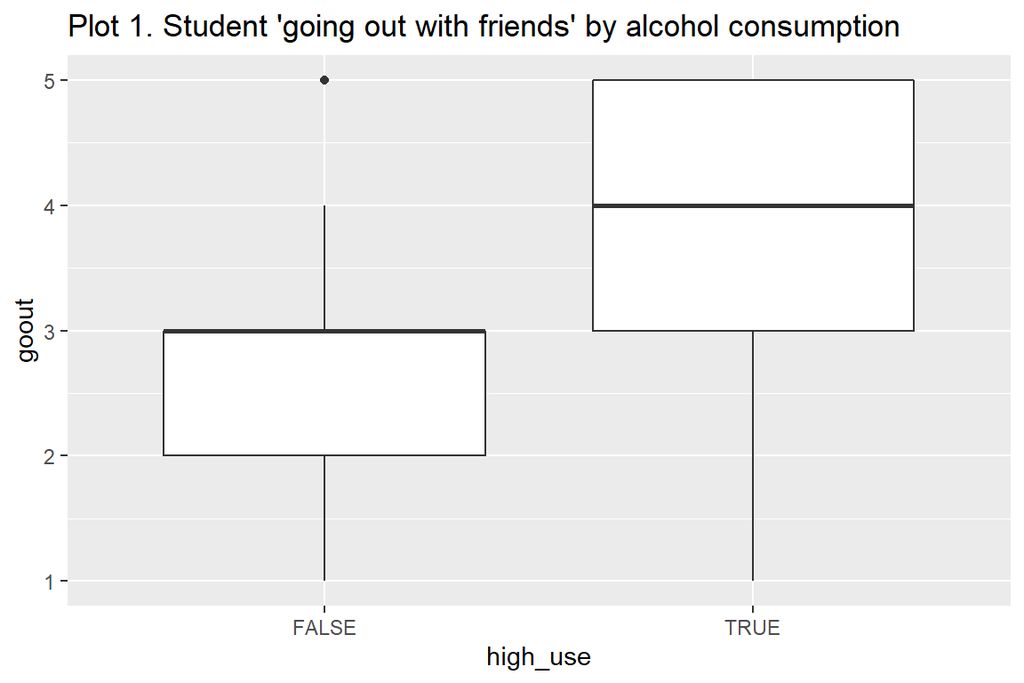

```r
g1 <- ggplot(alc, aes(x = high_use, y = goout))
g2 <- ggplot(alc, aes(x = high_use, y = health))
g3 <- ggplot(alc, aes(x = high_use, y = famrel))
g4 <- ggplot(alc, aes(x = romantic, y = high_use))

g1 + geom_boxplot() + ggtitle("Plot 1. Student 'going out with friends' by alcohol consumption")
```

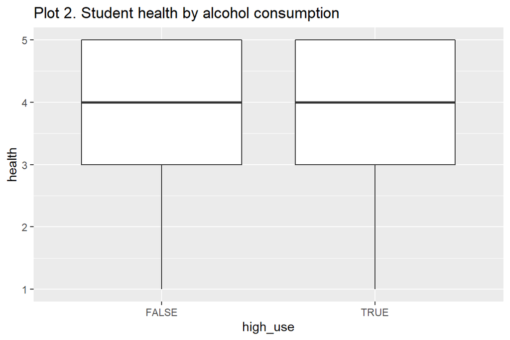

```r
g2 + geom_boxplot() + ggtitle("Plot 2. Student health by alcohol consumption")
```

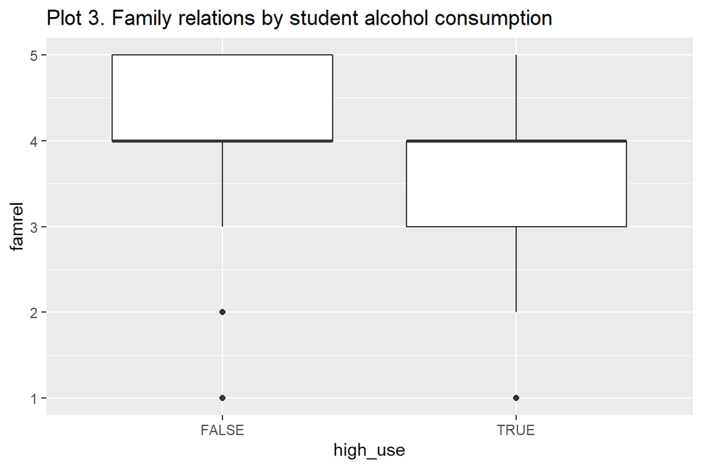

```r
g3 + geom_boxplot() + ggtitle("Plot 3. Family relations by student alcohol consumption")
```

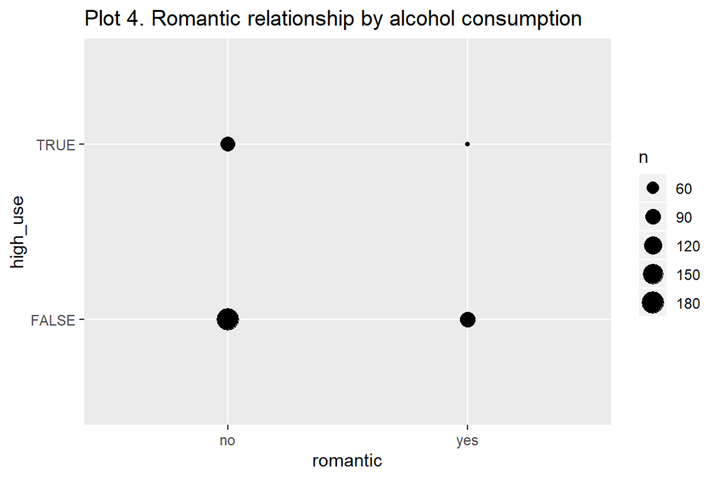

```r
g4 + geom_count() + ggtitle("Plot 4. Romantic relationship by alcohol consumption")
```

The last explanatory variable is binary. Visual inspection of the plot won’t be enough to determine any trends. I will make a table and calculate proportions for the columns to determine if a larger proportion among students without a romantic relationship are prone to high alcohol use. The table below shows a small difference between the groups.

```r
table(high_use = alc$high_use, romantic = alc$romantic) %>% prop.table(margin = 2) %>% addmargins()
```

```
##         romantic
## high_use        no       yes       Sum
##    FALSE 0.6896552 0.7272727 1.4169279
##    TRUE  0.3103448 0.2727273 0.5830721
##    Sum   1.0000000 1.0000000 2.0000000
```

## Preliminary analysis based on the plots

From studying the plots a few preliminary conclusions can be drawn about the hypotheses.

**Hypothesis 1:** Drinking is a social activity. High alcohol use will be more common among people who go out with their friends often.

**Preliminary analysis:** True. The boxplot shows a clear difference in high alcohol use between those who go out often with friends and those who don’t.

**Hypothesis 2:** Alcohol use increases health risks, therefore health will be worse among people with high alcohol consumtion.

**Preliminary analysis:** False. The boxplot shows no difference in health between high and low users of alcohol.

**Hypothesis 3:** High alcohol use will either be caused by bad family relationships or it will make family relationships worse, therefore a low quality of family relationships will correlate with high use of alcohol.

**Preliminary analysys:** True. The boxplot indicates that family relationships are worse among high alcohol users.

**Hypothesis 4:** When involved in a romantic relationship there is less loneliness and less time to spend with friends, which are both situations where use of alcohol is probable. Therefore being involved in a romantic relationship will decrease high alcohol use.

**Preliminary analysis:** Inconclusive. The trend indicates a small difference (27% high users in the group with a romantic relationship versus 31% in the group without) in favor of the hypothesis,

## Fitting a logistic regression model

In the next step, I will fit a regression model with the variables to see which ones have statistical significance.

```r
# find the model with glm()
m <- glm(high_use ~ goout + health + famrel + romantic, data = alc, family = "binomial")
# print out a summary of the model
summary(m)
```

```
##
## Call:
## glm(formula = high_use ~ goout + health + famrel + romantic,
##     family = "binomial", data = alc)
##
## Deviance Residuals:
##     Min       1Q   Median       3Q      Max
## -1.5457  -0.7757  -0.5371   0.9551   2.5006
##
## Coefficients:
##             Estimate Std. Error z value Pr(>|z|)
## (Intercept) -2.44591    0.68583  -3.566 0.000362 ***
## goout        0.81228    0.11948   6.798 1.06e-11 ***
## health       0.17186    0.09027   1.904 0.056946 .
## famrel      -0.41021    0.13648  -3.006 0.002649 **
## romanticyes -0.32282    0.26810  -1.204 0.228550
## ---
## Signif. codes:  0 '***' 0.001 '**' 0.01 '*' 0.05 '.' 0.1 ' ' 1
##
## (Dispersion parameter for binomial family taken to be 1)
##
##     Null deviance: 465.68  on 381  degrees of freedom
## Residual deviance: 403.26  on 377  degrees of freedom
## AIC: 413.26
##
## Number of Fisher Scoring iterations: 4
```

```r
# print out the coefficients of the model
coef(m)
```

```
## (Intercept)       goout      health      famrel romanticyes
##  -2.4459082   0.8122775   0.1718552  -0.4102130  -0.3228223
```

From the above regression model, we can see that **goout** and **famrel** have statistically significant effects. The variable **health** also points to a positive correlation, but the significance level is too low to include the variable in the final model. The effect of having a romantic relationship is not statistically significant.

Based on the above observations, I will create a new model with the ‘goout’ and ‘famrel’ variables.

```r
# find the model with glm()
m2 <- glm(high_use ~ goout + famrel, data = alc, family = "binomial")
# print out a summary of the model
summary(m2)
```

```
##
## Call:
## glm(formula = high_use ~ goout + famrel, family = "binomial",
##     data = alc)
##
## Deviance Residuals:
##     Min       1Q   Median       3Q      Max
## -1.5448  -0.7518  -0.5252   0.9872   2.3530
##
## Coefficients:
##             Estimate Std. Error z value Pr(>|z|)
## (Intercept)  -2.0289     0.6148  -3.300 0.000966 ***
## goout         0.7922     0.1183   6.698 2.11e-11 ***
## famrel       -0.3667     0.1338  -2.740 0.006142 **
## ---
## Signif. codes:  0 '***' 0.001 '**' 0.01 '*' 0.05 '.' 0.1 ' ' 1
##
## (Dispersion parameter for binomial family taken to be 1)
##
##     Null deviance: 465.68  on 381  degrees of freedom
## Residual deviance: 408.12  on 379  degrees of freedom
## AIC: 414.12
##
## Number of Fisher Scoring iterations: 4
```

```r
# print out the coefficients of the model
coef(m2) %>% exp
```

```
## (Intercept)       goout      famrel
##   0.1314829   2.2081701   0.6930400
```

From the above estimates we can see that going out often with friends is positivly correlated with high alcohol use. Having good family relationships is negativly correlated with high alcohol use.

Next, I will test the predictive power of the model

## Predicting results with the model

First, I will use the predict() function to calculate the probabilities for each of the observations based on the model. I am using the code from the data camp exercise for this. The probabilities will be stored in a new column that is added to the data frame.

```r
# predict() the probability of high_use
probabilities <- predict(m2, type = "response")

# add the predicted probabilities to 'alc'
alc <- mutate(alc, probability = probabilities)

# use the probabilities to make a prediction of high_use
alc <- mutate(alc, prediction = (probability > 0.5))

# see the last ten original classes, predicted probabilities, and class predictions
select(alc, goout, famrel, high_use, probability, prediction) %>% tail(10)
```

```
##     goout famrel high_use probability prediction
## 373     2      4    FALSE  0.12884377      FALSE
## 374     3      5     TRUE  0.18456437      FALSE
## 375     3      5    FALSE  0.18456437      FALSE
## 376     3      4    FALSE  0.24618632      FALSE
## 377     2      5    FALSE  0.09297087      FALSE
## 378     4      4    FALSE  0.41899693      FALSE
## 379     2      2    FALSE  0.23543261      FALSE
## 380     1      1    FALSE  0.16750946      FALSE
## 381     5      2     TRUE  0.76827688       TRUE
## 382     1      4     TRUE  0.06277392      FALSE
```

In order to see how the predictions turn out, I will tabulate the predictions and the actual values of the target variable.

```r
# tabulate the target variable versus the predictions
table(high_use = alc$high_use, prediction = alc$prediction)
```

```
##         prediction
## high_use FALSE TRUE
##    FALSE   243   25
##    TRUE     68   46
```

The above table shows that the prediction turned out to be correct in a majority of the cases. I will make a proportional table to get more information.

```r
# tabulate the target variable versus the predictions
table(high_use = alc$high_use, prediction = alc$prediction) %>% prop.table %>% addmargins
```

```
##         prediction
## high_use      FALSE       TRUE        Sum
##    FALSE 0.63612565 0.06544503 0.70157068
##    TRUE  0.17801047 0.12041885 0.29842932
##    Sum   0.81413613 0.18586387 1.00000000
```

From the above we can se that our predictions matched the results in about 76% of the cases (0.636 + 0.120 = 0.756.

Here is a graphical representation of the results:

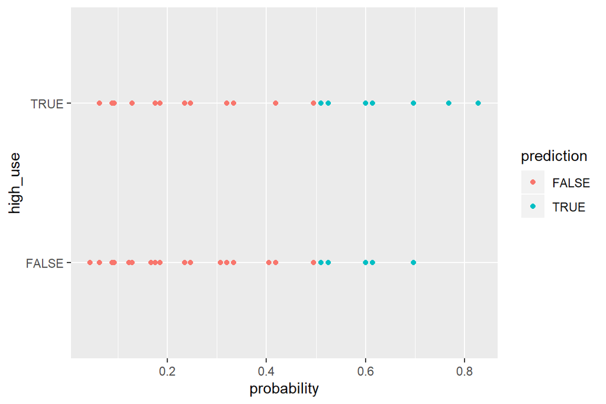

```r
# initialize a plot of 'high_use' versus 'probability' in 'alc'
g5 <- ggplot(alc, aes(x = probability, y = high_use, col = prediction))

# define the geom as points and draw the plot
g5 + geom_point()
```

Finally we will calculate the training error. I already manually computed that about 76% och the predictions were correct, so the training error should be around 24%. I will use the function fron the Data Camp exercise.

```r
# define a loss function (mean prediction error)
loss_func <- function(class, prob) {
  n_wrong <- abs(class - prob) > 0.5
  mean(n_wrong)
}

# call loss_func to compute the average number of wrong predictions in the (training) data
loss_func(class = alc$high_use, prob = alc$probability)
```

```
## [1] 0.2434555
```

The training error is 0.2434555, i.e. about 24% as expected.

I will end the analysis by performing the first bonus task: a 10-fold cross-validation on the model using the cv function.

```r
# K-fold cross-validation
library(boot)
cv <- cv.glm(data = alc, cost = loss_func, glmfit = m, K = 10)

# average number of wrong predictions in the cross validation
cv$delta[1]
```

```
## [1] 0.2486911
```

With this I will end the analysis, feeling that I have reached the end of both available time for further analysis and of my level of insight in the subject so far.

# IODS Exercise 4

Daniel Kawecki 24.11.2019

```r
# load MASS and Boston
  library(MASS)
```

```r
  data('Boston')

#Load ggplot2, GGally and dplyr
  library(ggplot2)
  library(GGally)
  library(dplyr)
```

## Data overview

```r
dim(Boston)
```

```
## [1] 506  14
```

```r
str(Boston)
```

```
## 'data.frame':    506 obs. of  14 variables:
##  $ crim   : num  0.00632 0.02731 0.02729 0.03237 0.06905 ...
##  $ zn     : num  18 0 0 0 0 0 12.5 12.5 12.5 12.5 ...
##  $ indus  : num  2.31 7.07 7.07 2.18 2.18 2.18 7.87 7.87 7.87 7.87 ...
##  $ chas   : int  0 0 0 0 0 0 0 0 0 0 ...
##  $ nox    : num  0.538 0.469 0.469 0.458 0.458 0.458 0.524 0.524 0.524 0.524 ...
##  $ rm     : num  6.58 6.42 7.18 7 7.15 ...
##  $ age    : num  65.2 78.9 61.1 45.8 54.2 58.7 66.6 96.1 100 85.9 ...
##  $ dis    : num  4.09 4.97 4.97 6.06 6.06 ...
##  $ rad    : int  1 2 2 3 3 3 5 5 5 5 ...
##  $ tax    : num  296 242 242 222 222 222 311 311 311 311 ...
##  $ ptratio: num  15.3 17.8 17.8 18.7 18.7 18.7 15.2 15.2 15.2 15.2 ...
##  $ black  : num  397 397 393 395 397 ...
##  $ lstat  : num  4.98 9.14 4.03 2.94 5.33 ...
##  $ medv   : num  24 21.6 34.7 33.4 36.2 28.7 22.9 27.1 16.5 18.9 ...
```

```r
summary(Boston)
```

```
##       crim                zn             indus            chas
##  Min.   : 0.00632   Min.   :  0.00   Min.   : 0.46   Min.   :0.00000
##  1st Qu.: 0.08204   1st Qu.:  0.00   1st Qu.: 5.19   1st Qu.:0.00000
##  Median : 0.25651   Median :  0.00   Median : 9.69   Median :0.00000
##  Mean   : 3.61352   Mean   : 11.36   Mean   :11.14   Mean   :0.06917
##  3rd Qu.: 3.67708   3rd Qu.: 12.50   3rd Qu.:18.10   3rd Qu.:0.00000
##  Max.   :88.97620   Max.   :100.00   Max.   :27.74   Max.   :1.00000
##       nox               rm             age              dis
##  Min.   :0.3850   Min.   :3.561   Min.   :  2.90   Min.   : 1.130
##  1st Qu.:0.4490   1st Qu.:5.886   1st Qu.: 45.02   1st Qu.: 2.100
##  Median :0.5380   Median :6.208   Median : 77.50   Median : 3.207
##  Mean   :0.5547   Mean   :6.285   Mean   : 68.57   Mean   : 3.795
##  3rd Qu.:0.6240   3rd Qu.:6.623   3rd Qu.: 94.08   3rd Qu.: 5.188
##  Max.   :0.8710   Max.   :8.780   Max.   :100.00   Max.   :12.127
##       rad              tax           ptratio          black
##  Min.   : 1.000   Min.   :187.0   Min.   :12.60   Min.   :  0.32
##  1st Qu.: 4.000   1st Qu.:279.0   1st Qu.:17.40   1st Qu.:375.38
##  Median : 5.000   Median :330.0   Median :19.05   Median :391.44
##  Mean   : 9.549   Mean   :408.2   Mean   :18.46   Mean   :356.67
##  3rd Qu.:24.000   3rd Qu.:666.0   3rd Qu.:20.20   3rd Qu.:396.23
##  Max.   :24.000   Max.   :711.0   Max.   :22.00   Max.   :396.90
##      lstat            medv
##  Min.   : 1.73   Min.   : 5.00
##  1st Qu.: 6.95   1st Qu.:17.02
##  Median :11.36   Median :21.20
##  Mean   :12.65   Mean   :22.53
##  3rd Qu.:16.95   3rd Qu.:25.00
##  Max.   :37.97   Max.   :50.00
```

The data frame contains data about 506 towns/suburbs in the Boston area. The 14 variables describe various housing, demographic, structural and social aspects of each town.

## Graphical overview of the data

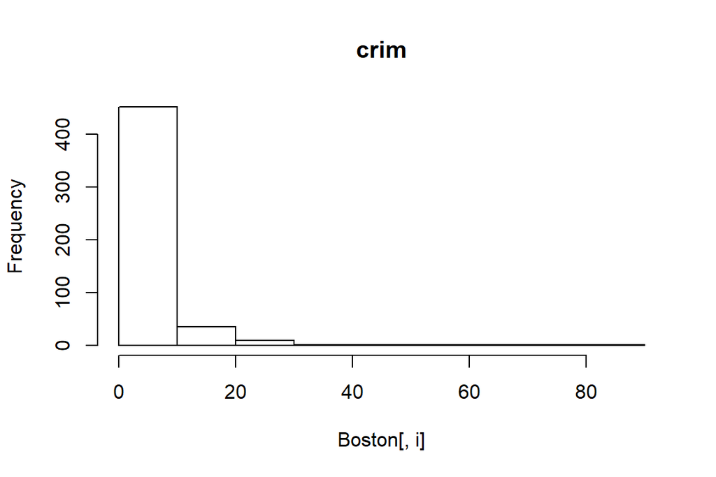

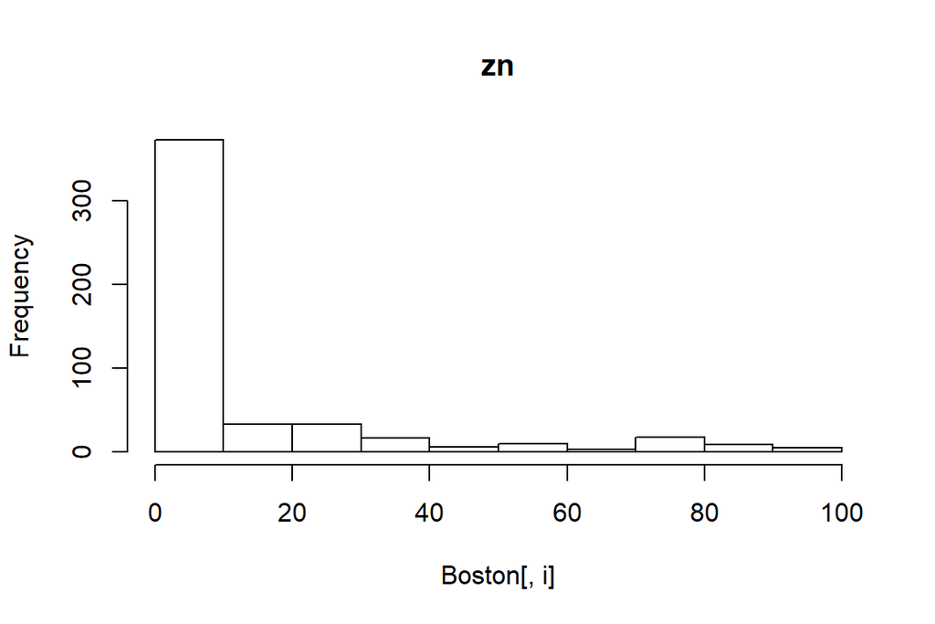

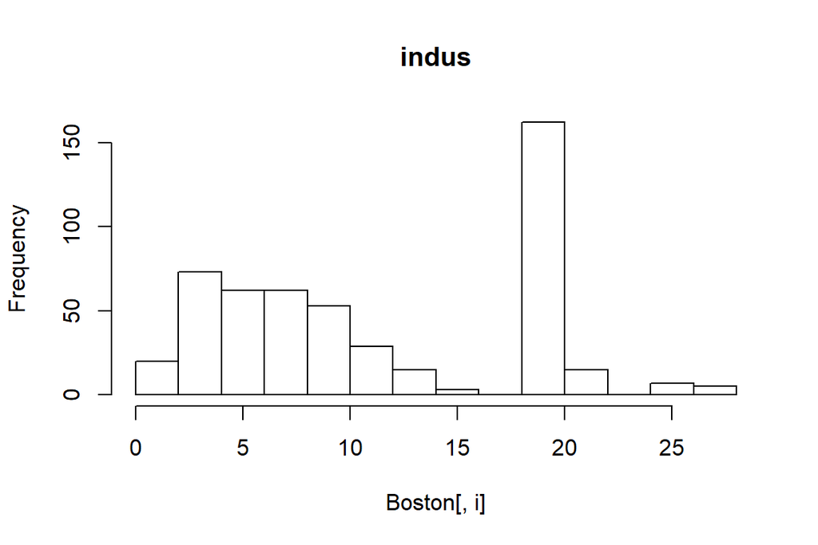

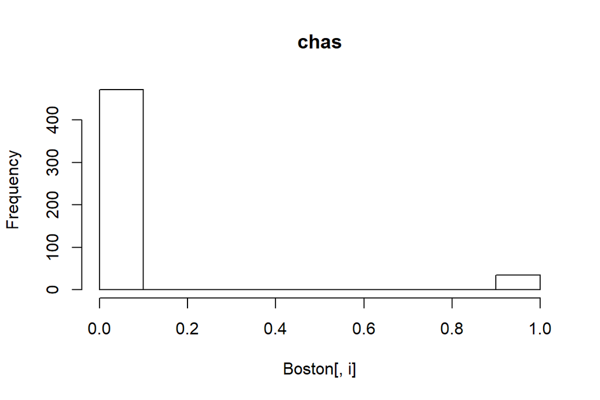

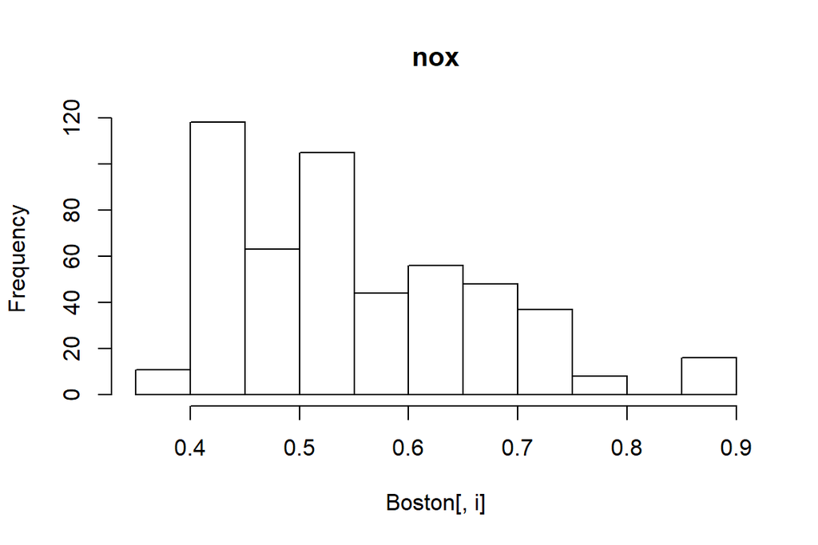

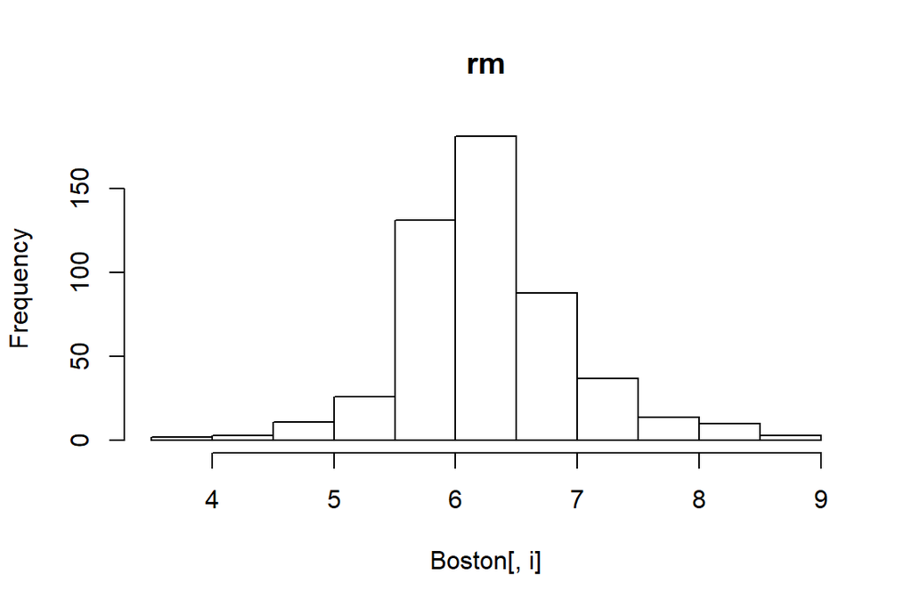

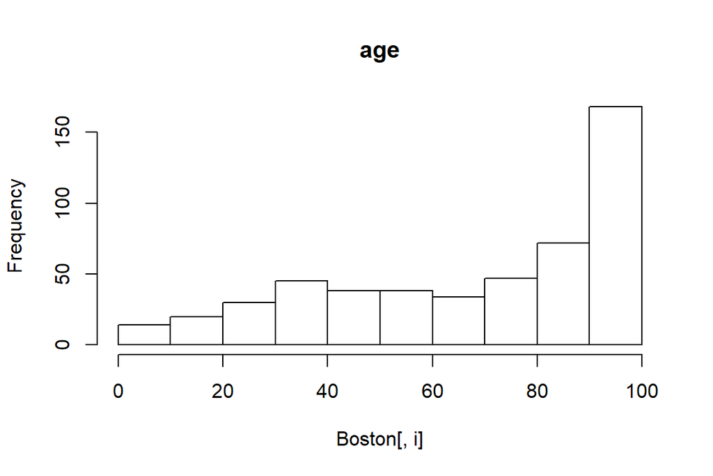

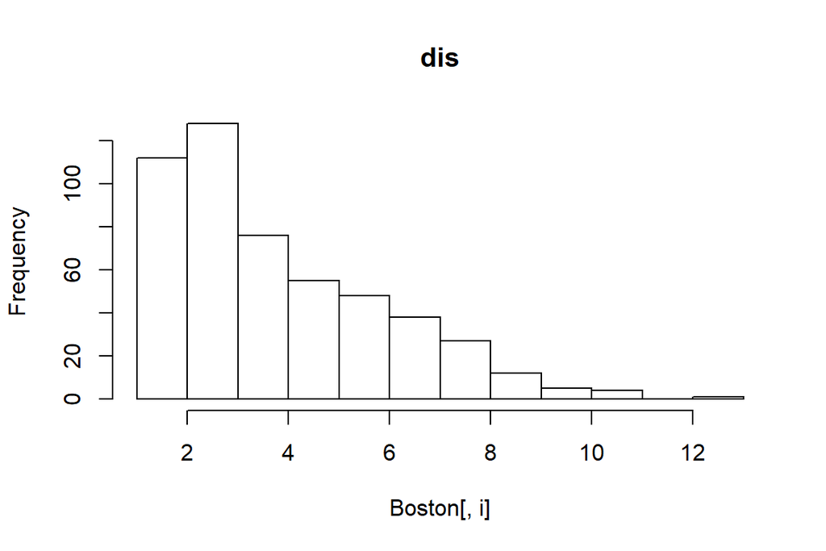

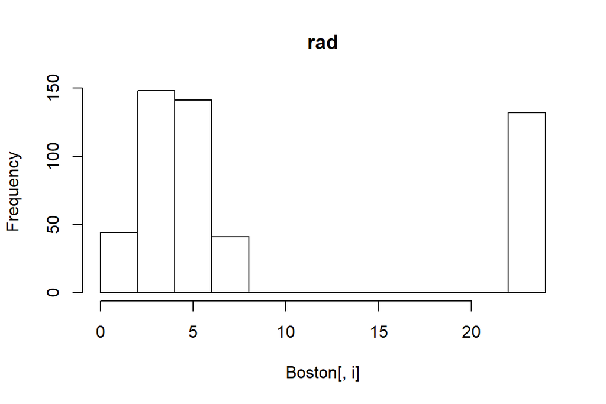

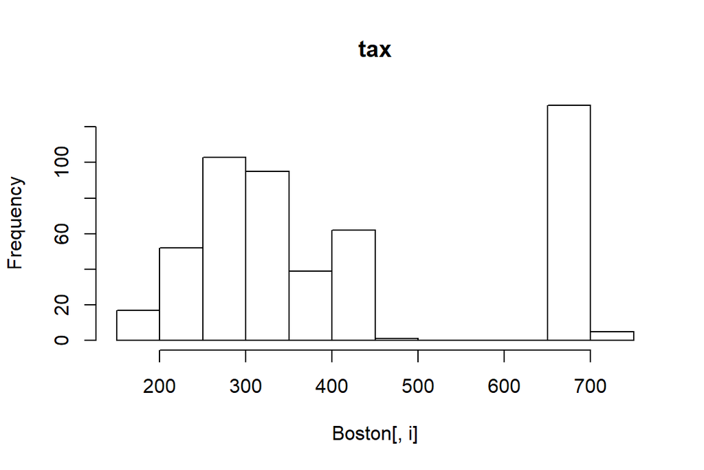

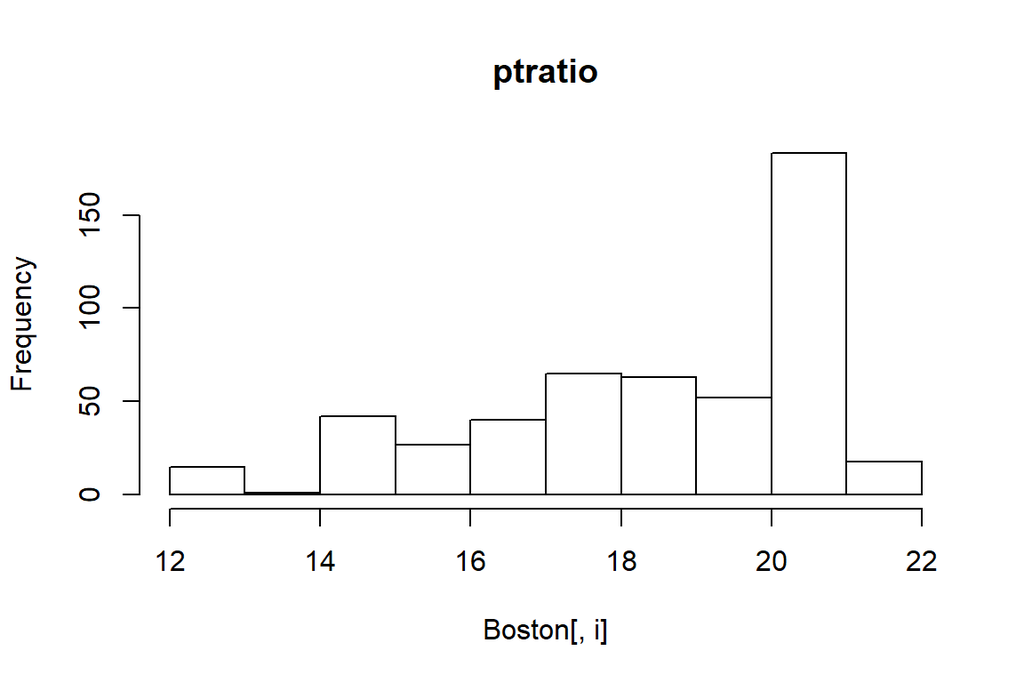

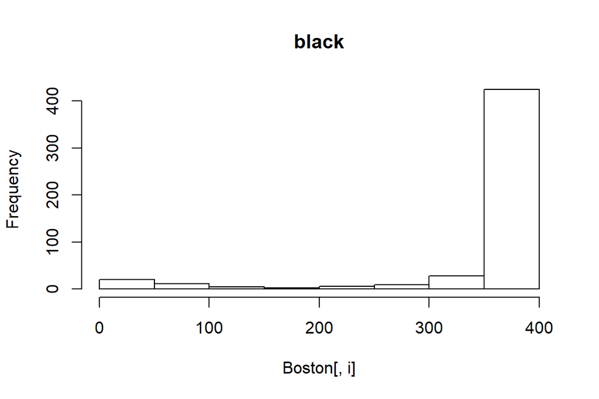

[2 more figures not shown]

```r
#Loop through the 14 columns
for (i in 1:14) {
  #Create histogram for each column
    hist(x = Boston[,i], main = colnames(Boston)[i])
}
```

Next, let’s look at the correlations with crime rate. I will also color accoring to proximity to the Charles River to detect any potential patterns through this dummy variable. I will end with a correlation plot for all variables.

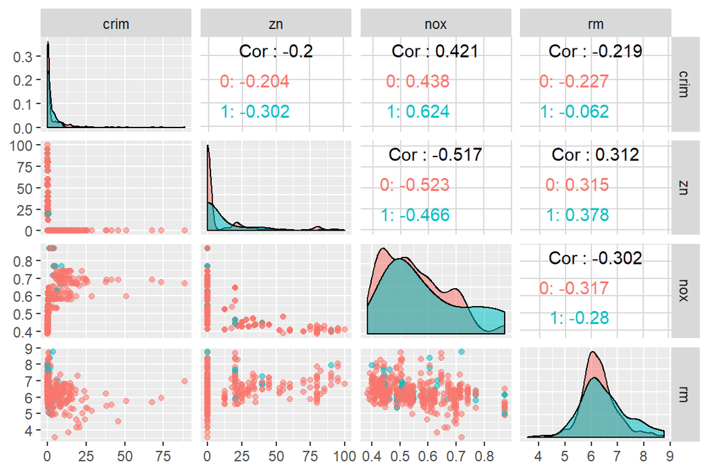

```r
ggpairs(Boston, columns = c("crim", "zn","nox","rm"), mapping = aes(col=as.factor(chas), alpha=0.5, legend = TRUE))
```

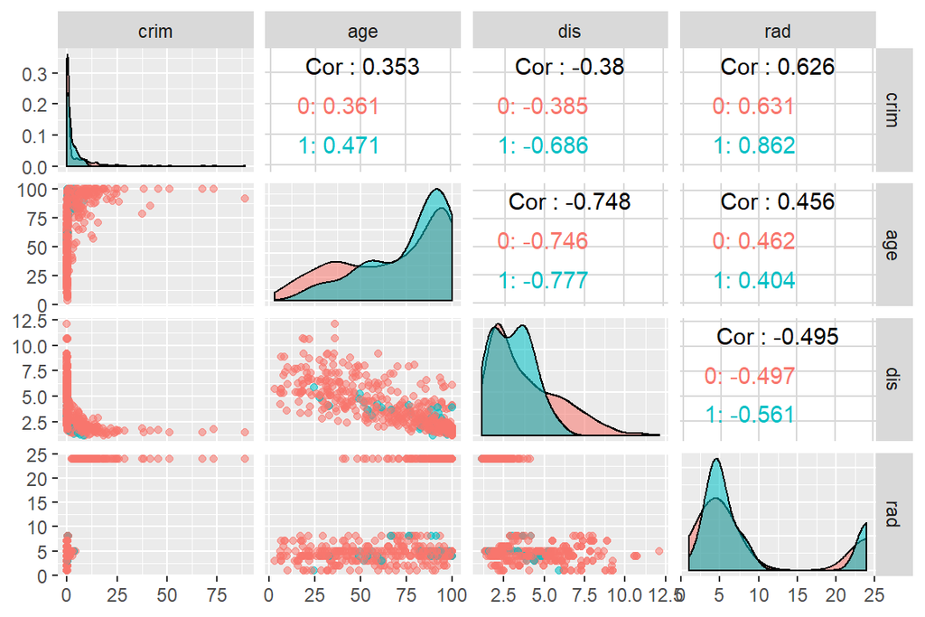

```r
ggpairs(Boston, columns = c("crim", "age","dis","rad"), mapping = aes(col=as.factor(chas), alpha=0.5, legend = TRUE))
```

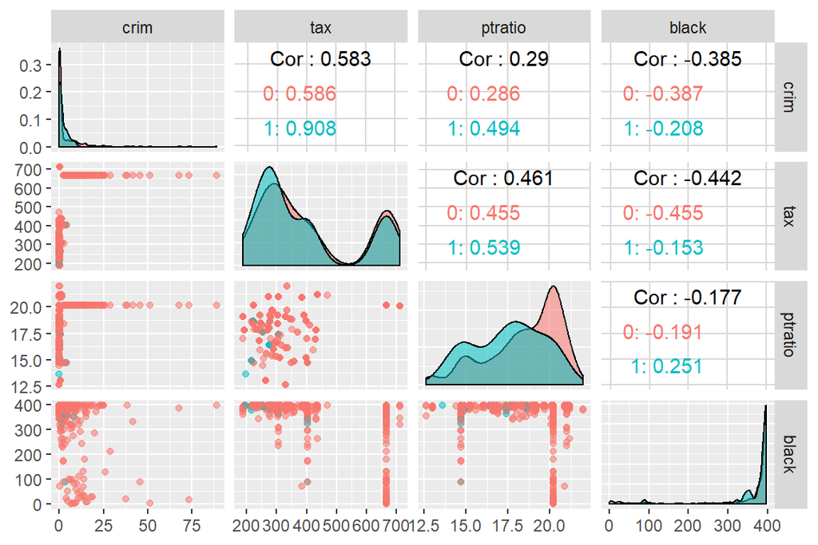

```r
ggpairs(Boston, columns = c("crim", "tax","ptratio","black"), mapping = aes(col=as.factor(chas), alpha=0.5, legend = TRUE))
```

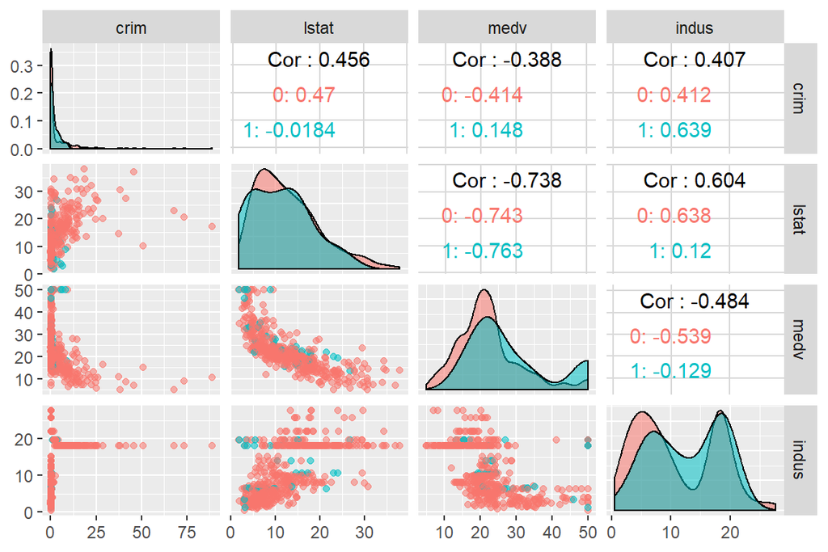

```r
ggpairs(Boston, columns = c("crim", "lstat","medv","indus"), mapping = aes(col=as.factor(chas), alpha=0.5, legend = TRUE))
```

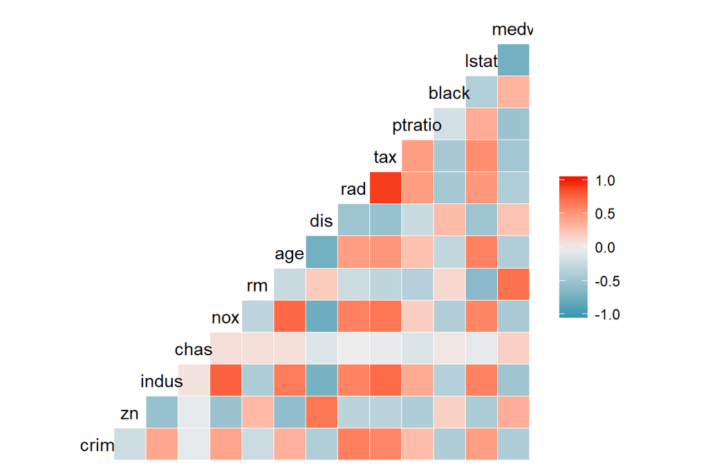

```r
ggcorr(Boston)
```

## Standardize the dataset

Next, the dataset will be standardized. As the summaries below show, the mean value of all variables is now 0 in the standardized data and the variable scales have changed.

```r
boston_scaled = scale(Boston)
# change the object to data frame
boston_scaled <- as.data.frame(boston_scaled)
summary(Boston)
```

```
##       crim                zn             indus            chas
##  Min.   : 0.00632   Min.   :  0.00   Min.   : 0.46   Min.   :0.00000
##  1st Qu.: 0.08204   1st Qu.:  0.00   1st Qu.: 5.19   1st Qu.:0.00000
##  Median : 0.25651   Median :  0.00   Median : 9.69   Median :0.00000
##  Mean   : 3.61352   Mean   : 11.36   Mean   :11.14   Mean   :0.06917
##  3rd Qu.: 3.67708   3rd Qu.: 12.50   3rd Qu.:18.10   3rd Qu.:0.00000
##  Max.   :88.97620   Max.   :100.00   Max.   :27.74   Max.   :1.00000
##       nox               rm             age              dis
##  Min.   :0.3850   Min.   :3.561   Min.   :  2.90   Min.   : 1.130
##  1st Qu.:0.4490   1st Qu.:5.886   1st Qu.: 45.02   1st Qu.: 2.100
##  Median :0.5380   Median :6.208   Median : 77.50   Median : 3.207
##  Mean   :0.5547   Mean   :6.285   Mean   : 68.57   Mean   : 3.795
##  3rd Qu.:0.6240   3rd Qu.:6.623   3rd Qu.: 94.08   3rd Qu.: 5.188
##  Max.   :0.8710   Max.   :8.780   Max.   :100.00   Max.   :12.127
##       rad              tax           ptratio          black
##  Min.   : 1.000   Min.   :187.0   Min.   :12.60   Min.   :  0.32
##  1st Qu.: 4.000   1st Qu.:279.0   1st Qu.:17.40   1st Qu.:375.38
##  Median : 5.000   Median :330.0   Median :19.05   Median :391.44
##  Mean   : 9.549   Mean   :408.2   Mean   :18.46   Mean   :356.67
##  3rd Qu.:24.000   3rd Qu.:666.0   3rd Qu.:20.20   3rd Qu.:396.23
##  Max.   :24.000   Max.   :711.0   Max.   :22.00   Max.   :396.90
##      lstat            medv
##  Min.   : 1.73   Min.   : 5.00
##  1st Qu.: 6.95   1st Qu.:17.02
##  Median :11.36   Median :21.20
##  Mean   :12.65   Mean   :22.53
##  3rd Qu.:16.95   3rd Qu.:25.00
##  Max.   :37.97   Max.   :50.00
```

```r
summary(boston_scaled)
```

```
##       crim                 zn               indus
##  Min.   :-0.419367   Min.   :-0.48724   Min.   :-1.5563
##  1st Qu.:-0.410563   1st Qu.:-0.48724   1st Qu.:-0.8668
##  Median :-0.390280   Median :-0.48724   Median :-0.2109
##  Mean   : 0.000000   Mean   : 0.00000   Mean   : 0.0000
##  3rd Qu.: 0.007389   3rd Qu.: 0.04872   3rd Qu.: 1.0150
##  Max.   : 9.924110   Max.   : 3.80047   Max.   : 2.4202
##       chas              nox                rm               age
##  Min.   :-0.2723   Min.   :-1.4644   Min.   :-3.8764   Min.   :-2.3331
##  1st Qu.:-0.2723   1st Qu.:-0.9121   1st Qu.:-0.5681   1st Qu.:-0.8366
##  Median :-0.2723   Median :-0.1441   Median :-0.1084   Median : 0.3171
##  Mean   : 0.0000   Mean   : 0.0000   Mean   : 0.0000   Mean   : 0.0000
##  3rd Qu.:-0.2723   3rd Qu.: 0.5981   3rd Qu.: 0.4823   3rd Qu.: 0.9059
##  Max.   : 3.6648   Max.   : 2.7296   Max.   : 3.5515   Max.   : 1.1164
##       dis               rad               tax             ptratio
##  Min.   :-1.2658   Min.   :-0.9819   Min.   :-1.3127   Min.   :-2.7047
##  1st Qu.:-0.8049   1st Qu.:-0.6373   1st Qu.:-0.7668   1st Qu.:-0.4876
##  Median :-0.2790   Median :-0.5225   Median :-0.4642   Median : 0.2746
##  Mean   : 0.0000   Mean   : 0.0000   Mean   : 0.0000   Mean   : 0.0000
##  3rd Qu.: 0.6617   3rd Qu.: 1.6596   3rd Qu.: 1.5294   3rd Qu.: 0.8058
##  Max.   : 3.9566   Max.   : 1.6596   Max.   : 1.7964   Max.   : 1.6372
##      black             lstat              medv
##  Min.   :-3.9033   Min.   :-1.5296   Min.   :-1.9063
##  1st Qu.: 0.2049   1st Qu.:-0.7986   1st Qu.:-0.5989
##  Median : 0.3808   Median :-0.1811   Median :-0.1449
##  Mean   : 0.0000   Mean   : 0.0000   Mean   : 0.0000
##  3rd Qu.: 0.4332   3rd Qu.: 0.6024   3rd Qu.: 0.2683
##  Max.   : 0.4406   Max.   : 3.5453   Max.   : 2.9865
```

## Create categorical variable from crime

The categorical variable will divide the observation in four equally lare parts based on the quantiles of the data. Each part of the observations will be labled from low to high.

```r
#Create the bins based on quantiles
bins <- quantile(boston_scaled$crim)

# create a categorical variable 'crime'
crime <- cut(boston_scaled$crim, breaks = bins, include.lowest = TRUE, label = c("low","med_low","med_high","high"))

# look at the table of the new factor crime
table(crime)
```

```
## crime
##      low  med_low med_high     high
##      127      126      126      127
```

```r
# remove original crim from the dataset
boston_scaled <- dplyr::select(boston_scaled, -crim)

# add the new categorical value to scaled data
boston_scaled <- data.frame(boston_scaled, crime)
```

## Divide the dataset to train and test sets

80% of the observations will be used for training the model to make predictions and 20% will be used to test the predictions.

```r
# number of rows in the Boston dataset
n <- nrow(boston_scaled)

# choose randomly 80% of the rows
ind <- sample(n,  size = n * 0.8)

# create train set
train <- boston_scaled[ind,]

# create test set
test <- boston_scaled[-ind,]

# save the correct classes from test data
correct_classes <- test$crime

# remove the crime variable from test data
test <- dplyr::select(test, -crime)
```

## Fit the linear discriminant analysis on the train set

We fit a linear discriminant analysis using all variables on crime as target variable.

```r
# linear discriminant analysis
lda.fit <- lda(crime ~ ., data = train)

# print the lda.fit object
lda.fit
```

```
## Call:
## lda(crime ~ ., data = train)
##
## Prior probabilities of groups:
##       low   med_low  med_high      high
## 0.2425743 0.2549505 0.2747525 0.2277228
##
## Group means:
##                   zn      indus        chas        nox          rm
## low       0.91261081 -0.8966105 -0.11163110 -0.8738381  0.48143370
## med_low  -0.08615163 -0.3258744 -0.08120770 -0.5606591 -0.08765207
## med_high -0.38603469  0.2043174  0.18877276  0.3836640  0.10114800
## high     -0.48724019  1.0173395 -0.01556166  1.0784475 -0.35515296
##                 age        dis        rad        tax     ptratio
## low      -0.8779636  0.8417918 -0.6877230 -0.7459897 -0.44985009
## med_low  -0.3641924  0.3477429 -0.5414397 -0.4358711 -0.06825419
## med_high  0.4460795 -0.4089512 -0.4055684 -0.2990933 -0.29821706
## high      0.8557027 -0.8740005  1.6358846  1.5124511  0.77816452
##                black       lstat        medv
## low       0.37734256 -0.77496653  0.53176120
## med_low   0.31380180 -0.16770985  0.02219034
## med_high  0.05411655  0.03252347  0.16902941
## high     -0.86709136  0.82950794 -0.66079186
##
## Coefficients of linear discriminants:
##                 LD1          LD2         LD3
## zn       0.17616352  0.604905151 -1.09845201
## indus    0.02675222 -0.286467004 -0.08680901
## chas    -0.07792338 -0.024690441  0.05940417
## nox      0.39808285 -0.719617158 -1.19087518
## rm      -0.12733556 -0.049642599 -0.15476172
## age      0.38284787 -0.328220091 -0.25888276
## dis     -0.06449192 -0.156787924  0.09253233
## rad      3.11521130  0.911619075 -0.55084947
## tax     -0.17107650  0.094625204  1.24487881
## ptratio  0.13296799  0.027641321 -0.25759543
## black   -0.14791167  0.005518703  0.12959396
## lstat    0.20078239 -0.229490548  0.43071597
## medv     0.17788157 -0.373071697 -0.08134473
##
## Proportion of trace:
##    LD1    LD2    LD3
## 0.9406 0.0446 0.0147
```

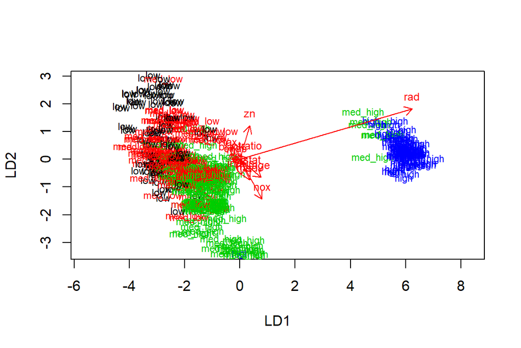

```r
# the function for lda biplot arrows
lda.arrows <- function(x, myscale = 1, arrow_heads = 0.1, color = "red", tex = 0.75, choices = c(1,2)){
  heads <- coef(x)
  arrows(x0 = 0, y0 = 0,
         x1 = myscale * heads[,choices[1]],
         y1 = myscale * heads[,choices[2]], col=color, length = arrow_heads)
  text(myscale * heads[,choices], labels = row.names(heads),
       cex = tex, col=color, pos=3)
}

# target classes as numeric
classes <- as.numeric(train$crime)

# plot the lda results
plot(lda.fit, dimen = 2, col = classes, pch = classes)
lda.arrows(lda.fit, myscale = 2)
```

## Prediction

Based on the model, we predict the outcome from the test data and compare to the actual values of the test data.

```r
lda.pred <- predict(lda.fit, newdata = test)
table(correct = correct_classes, predicted = lda.pred$class)
```

```
##           predicted
## correct    low med_low med_high high
##   low       17      10        2    0
##   med_low    4      14        5    0
##   med_high   1       4       10    0
##   high       0       0        0   35
```